# Data Science para Economía y Negocios - Clase 1

3/17/2020

## Introducción

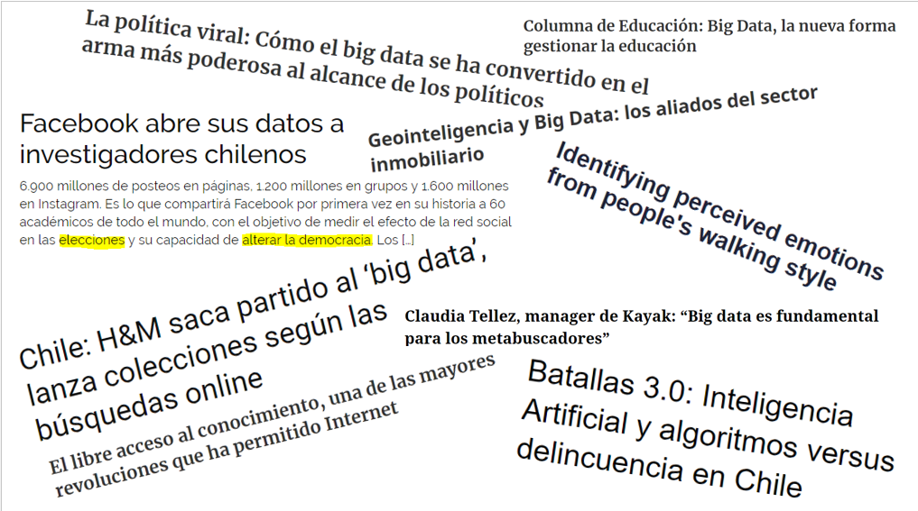

## “Llueven Datos”

## Introducción

Cumulus media (2017): En un minuto de internet…

- 3.5 millones de búsquedas en google
- 900.000 personas se conectan a Facebook
- Se reproducen 4.1 millones de horas de videos en Youtube
- Se envían 450.000 tweets
- Se reproducen 70.000 horas de contenido en Netflix
- Se suben 46.200 fotos en instagram

## Pero… ¿ más datos = más conocimiento?

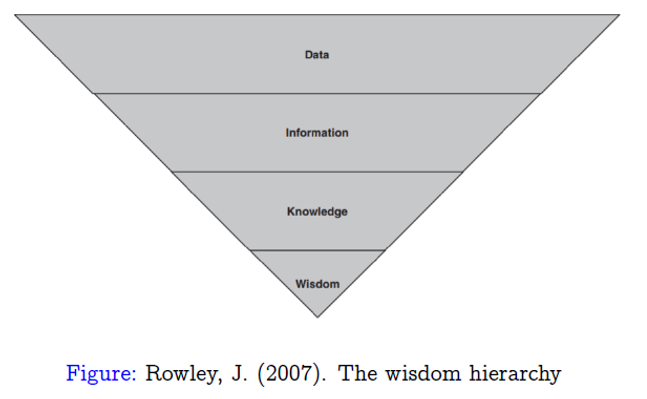

## ¿Qué es Data Science?

Campo interdisiplinario que se encarga de extraer conocimiento de datos y generar análisis sobre estos

- Matemáticas
- Estadística
- Ciencias de computación

## ¿Qué es Data Science?

“The ability to take data - to be able to understand it, to process it, to extract value from, to visualize it, to communicate it - that’s going to be a hugely important skill in the next decades”

**Hal Varian, Economista Jefe de Google y Académico de UC Berekeley (2009)**

## ¿Qué es Data Science?

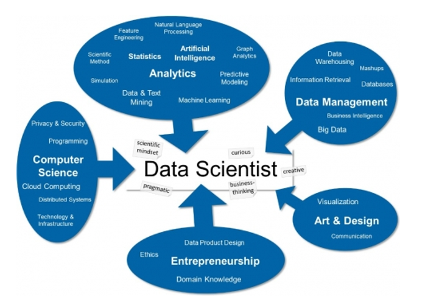

## ¿Qué es Big Data?

Datos que contienen una mayor **V**ariedad y que se presentan en **V**olúmenes crecientes y a una **V**elocidad superior (Gartnet,2001):

- Volumen: Muchos!
- Variedad: Datos estructurados - no estructurados
- Velocidad: Tiempo real

## ¿Qué es Big Data?

- Valor
- Veracidad

## ¿Por qué estudiar Data Science?

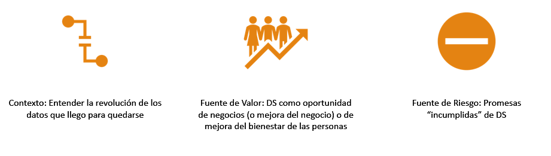

## ¿Por qué estudiar Data Science?

[figure not shown]

## ¿Por qué estudiar Data Science?

[figure not shown]

## ¿Por qué estudiar Data Science?

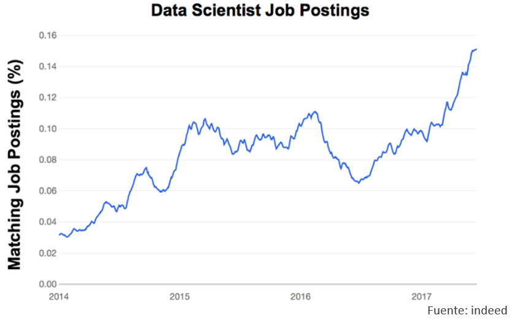

## En este curso…

- Repasaremos los tópicos principales de los que se ocupa DS desde un enfoque **“Práctico”**
- Utilizaremos el software de estadístico R como una **herramienta** para desarrollar nuestros fines. **El software nunca es el fin en si mismo!!**
- Las clases se enfocarán en la resolución de problemas para el análisis económico y aplicaciones para los negocios

## Objetivos del curso

- Desarrollar la capacidad de conceptualización abstracta de estructura de datos y cómo estas se enlazan con metodologías para responder preguntas básicas que sirvan de apoyo a la toma de decisiones
- Entender y aplicar la generación de información desde datos ‘crudos’
- Aprender a trabajar datos de manera ordenada y sistemática con el fin de lograr generar proyectos que sean reproductibles
- Brindar a estudiantes una introducción al lenguaje estadístico R

## Estructura del curso

1. Natación 101 para DS
   - Introducción a la programación en R y Manejo de Datos
2. Buscando la aguja en el pajar: Visualización de Datos
3. Obsesivo de los Datos vs. Teórico conservador
   - El dilema actual de un buen Científico de Datos

## 1. Natación 101 para DS

- Se entregan las primeras indicaciones y el contexto de este “mar de datos” que nos proponemos nadar
- Se entregarán las herramientas básicas de programación en R para abordar los objetivos del curso:
  - Introducción a paquetes y/o funciones para el análisis de datos
  - Análisis y manipulación de los diferentes tipos de objetos en R
  - Entender el nexo entre el manejo de base de datos y la solución de problemas de negocios y/o toma de decisiones

## 2. Buscando la aguja en el pajar: Visualización de Datos

- Veremos como a través de los datos podemos:
  - Caracterizar clientes
  - Segmentar demandas
  - Identificar sujetos de política pública
  - Etc.
- Realizar análisis en términos exploratorios de forma visual para generar contexto, detectar problemas y posteriormente realizar alguna hipótesis de interés
- Generar visualizaciones potentes que nos permitan captar la atención y mostrar dinámicas interesantes

https://www.gapminder.org/tools

## 3. Obsesivo de los Datos vs. Teórico conservador

- Entender la discusión de los enfoques de DS: Desde el enfoque “Data driven” hasta la “vieja” teoría estadística
- Técnicas y herramientas de DS y su utilidad en la economía y en los negocios
- Pequeñísima introducción a ML:
  - Aprendizaje Supervisado
    - New is always better? Regresión lineal
    - Validación cruzada
  - Aprendizaje no Supervisado
    - Análisis de Cluster

## Una mirada del curso

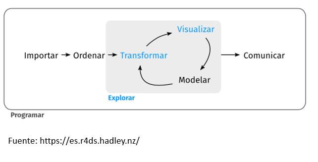

## Evaluación

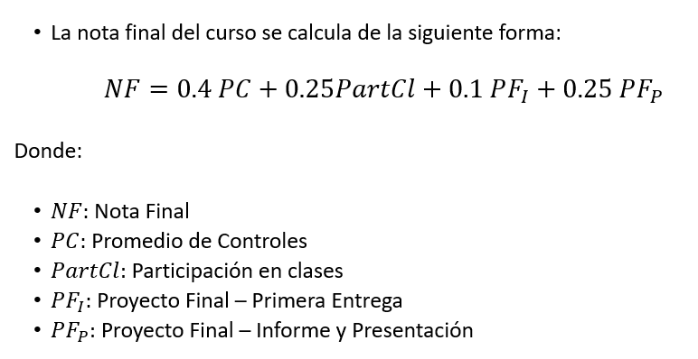

## ¡Bienvenidos y Bienvenidas!